# بنام خدا

Hossein Vatani

March 18, 2016

# R1-GettingStart

# شروع کار با نرم افزار R

*مقدمه متن پیش رو ترجمه ای با اندکی تلخیص از یازده مقاله دانشگاه کلمبیا آمریکا در مورد نرم افزار قدرتمندR می باشد.متن انگلیسی آن نیز در همین سایت موجود است.*

## ۱-آماده سازی نرم افزار

نرم افزار R یک زبان برنامه نویسی و محیطی برای انجام عملیات و محاسبات آماری و همینطور نمایش آن می باشد. این زبان در سالهای اخیر بخاطر انعطاف بسیار زیاد خود،جهت توسعه و توضیح مدلهای جدید آماری بسیار مورد توجه قرار گرفته است. این نرم افزار در تمام آزمایشگاه های سراسر دانشگاه کلمبیا آمریکا نصب و در حال استفاده می باشد. نرم افزار R بصورت رایگان و متن باز و تحت موجز GNU می باشد که شما می تواند آنرا از آدرس زیر دریافت و نصب نمایید. [سایت اصلی نرم افزار](http://www.r-project.org)

نرم افزار R بصورت محیط فرمان (comman Line) می باشد که البته برای آن واسط های گرافیکی خوبی طراحی شده است.یکی از بهترین و معروفترین آنها واسط گرافیکی RStudio می باشد که از آدرس [دریافت واسط گرافیکی](https://www.rstudio.com/products/rstudio/download). پس از نصب این رابط گرافیکی و اجرای آن با محیطی مانند تصویر پایین مواجه خواهید شد.

[figure not shown]

*محیط نرم افزار RStudio*

با توجه به این موضوع که در این سری از مقاله ها قصد اشنایی با عملکرد و نحوه استفاده از نرم افزارR می باشد،به همین توضیح که قسمت پایین سمت چپ محیط خط فرمان و محل اجرا کردن دستورات این مطالب می باشد، بسنده می کنیم. در هر محیط خط فرمانی یک علامت جهت مشخص کردن ابتدای خط فرمان وجود دارد که برای محیط R علامت “<” می باشد. برای این نرم افزار مجموعه داده(Datasets)های فراوانی جهت کار و یادگیری ارائه شده است که برخی با نصب خود زبان R در نرم افزار نصب می شوند ،برخی بهمراه بسته های جدید نصب می شوند و برخی دیگر نیر خود بتنهایی قابل نصب بر روی این نرم افزار هستند. جهت دیدن لیست مجموعه داده های موجود از دستور زیر استفاده کنید

```r
library(help = "datasets")#جهت نمایش تمام مجموعه داده های موجود در نرم افزار نصب شده در این سیستم
```

سه دستور زیر را نیز ملاحظه نمایید

```r
objects()         # جهت نمایش تمامی اشیا تعریف شده در نرم افزار،بدیهی است اجرا در ابتدای اجرای برنامه مقدار خالی برمی گرداند
help(command_name)# جهت نمایش صفحه راهنمای دستور
q()               # جهت خروج از برنامه
```

با اجرای آخرین دستور از شما پرسیده خواهدکه آیا تمایل به ذخیره برنامه دارید یا خیر.

## ۲-بیاید شروع کنیم

### الف-عملگرها

شما می توانید تمام عملیات ها ، دستورات و تابع های معمولی موجود در ریاضیات را بسادگی اجرا نمایید.

```r
2 + 2
9 - 2
10*10
25/5
3 ^ 2       # عدد سه بتوان دو.
100^(1/2)
sqrt(100)   # ریشه عدد ۱۰۰.
log(10)     # لگاریتم طبیعی عدد ۱۰.
log10(1000) # لگاریتم عدد ۱۰۰۰ در مبنای ۱۰.
exp(2)      # عدد e بتوان دو.
cos(pi/4)   # تابع کسینوس.
```

### ب-بردار و ماتریس

نگاه عملگرهای R و ماهیت عمل آنها بر یک مجموعه ای از داده هاست، بعبارتی دیگر در R داده ای بعنوان عدد یا رشته نداریم بلکه برداری عددی یا رشته ای ویا… داریم. ساده ترین نوع داده ای بردار می باشد که آرایه ای از عددها ویا حرفها می باشد.

```r
x = c(3,4,7,8) # ایجاد یک بردار با اعداد 3,4,7,8
x # نماش آن
```

```
## [1] 3 4 7 8
```

```r
y = 1:4 # ایجاد یک تابع از عدد ۱ تا ۴
y
```

```
## [1] 1 2 3 4
```

```r
z = seq(0,1,0.1) # ایجاد یک بردار از عدد ۰ تا ۱ باگام ۰.۱
z
```

```
##  [1] 0.0 0.1 0.2 0.3 0.4 0.5 0.6 0.7 0.8 0.9 1.0
```

*اگر تابعی مانند seq نا آشناست می تواندید بادستور راهنماتوضیحات آنرا مشاهده نمایید*

جهت دسترسی به هریک از اعضای بردار

```r
x[1]
```

```
## [1] 3
```

```r
z[1:3]
```

```
## [1] 0.0 0.1 0.2
```

اکنون نحوه استفاده از عملگرها بروی این بردارها(پایه ای ترین نوع داده) را باهم ملاحظه می کنیم.

```r
x+y
```

```
## [1]  4  6 10 12
```

```r
x*z #لطفا توجه نمایید که چون یکی از عملوندها از دیگری کوچکتر است، ادامه ضرب از ابتدای عضو کوچکتر ادامه می یابد
```

```
##  [1] 0.0 0.4 1.4 2.4 1.2 2.0 4.2 5.6 2.4 3.6 7.0
```

```r
sqrt(x)
```

```
## [1] 1.732051 2.000000 2.645751 2.828427
```

```r
y/x
```

```
## [1] 0.3333333 0.5000000 0.4285714 0.5000000
```

```r
z^2
```

```
##  [1] 0.00 0.01 0.04 0.09 0.16 0.25 0.36 0.49 0.64 0.81 1.00
```

```r
cos(z)+x*3/log(y) #یا هرچیز دیگری که دوست دارید!
```

```
##  [1]      Inf 18.30734 20.09509 18.26768      Inf 18.18992 19.94036
##  [8] 18.07718      Inf 17.93395 19.65533
```

بردارها را می توان از نوع حروف و رشته ای نیز تعریف کرد.

```r
Names = c("Mohammad","Ali","Hassan","Hossein")
Names
```

```
## [1] "Mohammad" "Ali"      "Hassan"   "Hossein"
```

اما یک بردار از دو نوع عددی و رشته ای

```r
Combine=c(1:3,letters[1:3])
Combine
```

```
## [1] "1" "2" "3" "a" "b" "c"
```

نوع داده بعدی ، ماتریس می باشد که در چند حالت می توان تعریف کرد.

```r
M1=matrix(c(x,y), nrow = 2, ncol = 4)
M1
```

```
##      [,1] [,2] [,3] [,4]
## [1,]    3    7    1    3
## [2,]    4    8    2    4
```

```r
M1[1,]
```

```
## [1] 3 7 1 3
```

```r
M1[,2]
```

```
## [1] 7 8
```

```r
M1[1:2,3:4]
```

```
##      [,1] [,2]
## [1,]    1    3
## [2,]    2    4
```

```r
M2=cbind(x,y)
M2
```

```
##      x y
## [1,] 3 1
## [2,] 4 2
## [3,] 7 3
## [4,] 8 4
```

```r
M3=rbind(x,y)
M3
```

```
##   [,1] [,2] [,3] [,4]
## x    3    4    7    8
## y    1    2    3    4
```

توضیح آنکه

```
nrow=یعنی تعداد سطرها
ncol=به معنی تعداد ستونها
cbind=یعنی هریک از نوع-داده های  آورده شده در رابطه(که در اینجا از نوع بردار می باشند) را یک ستون در نظر بگیر
rbind=همان بالایی فقط بصورت سر
```

عملیات های روی ماتریس

```r
M4=M1%*%M2 #ضرب ماتریس ها
M4
```

```
##       x  y
## [1,] 68 32
## [2,] 90 42
```

```r
t(M4) # ترانهاده ماتریس
```

```
##   [,1] [,2]
## x   68   90
## y   32   42
```

```r
solve(M4) #معکوس کاتریس
```

```
##    [,1]      [,2]
## x -1.75  1.333333
## y  3.75 -2.833333
```

## ج-قاب-داده(Data Frame)

پرکاربردترین نوع داده می باشد که تقریبا می توان گفت همان نوع ماتریس است با این تفاوت که نوع داده ستونها می تواند متفاوت باشد. در واقع لازم است که طول ستونها باهم برابر باشد. البته دونوع داده Na و NaN وجود دارد که در صورت برابر نبودن طول ستونها باتوجه به نوع دستورات داده شده،برای یکسان سازی طول داده ها R آنها را در انتهای ستون های کوچکتر اضافه می کند.

```r
A=c(TRUE,TRUE,FALSE,FALSE)
B=c("Mohammad","Ali","Hassan","Hossein")
Df=data.frame(x,A,B)
Df
```

```
##   x     A        B
## 1 3  TRUE Mohammad
## 2 4  TRUE      Ali
## 3 7 FALSE   Hassan
## 4 8 FALSE  Hossein
```

در قاب داده اعضای هر ستون از یک نوع داده می باشد و اعضای هر سطر ممکن است از انواع متفاوت داده باشند. دسترسی به اعضا همانند ماتریس بعلاوه بسیاری از نحوه دسترسی های دیگر. با دستور cbind()می توان ستون های دیگری نیز به قاب-داده اضافه نمود

```r
Df=cbind(Df,c(.5,1.5,8.1,3.7))
Df
```

```
##   x     A        B c(0.5, 1.5, 8.1, 3.7)
## 1 3  TRUE Mohammad                   0.5
## 2 4  TRUE      Ali                   1.5
## 3 7 FALSE   Hassan                   8.1
## 4 8 FALSE  Hossein                   3.7
```

قاب-داده را می توان با فراخوانی محیطی شبیه صفحه گسترده(مانند libreoffice در لینوکس ویا اکسل در ویندوز) از محیط R تعریف کرد.

```r
Df2=edit(data.frame())
```

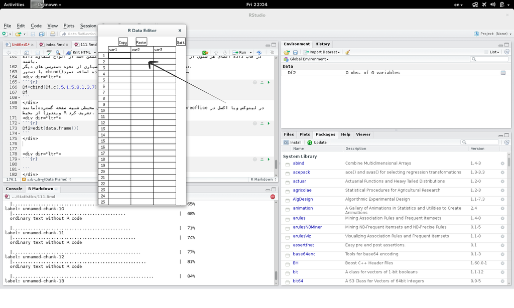

*نکته اول:توجه شود با بزرگتر کردن صفحه ، ستونهای بیشتری نمایان می شود.*

*نکته دوم: با کلیک بر روی نام ستون می توانید نام ستون را تغییر دهید.*

*یک نوع داده ای از نسل قاب داده بانام جدول-داده(Data.Table) تولید شده است که بسیار قوی و کاربردی است، چون مقصد این مباحث نیست از ان عبور می کنیم و اگر عمر و توفیق بود در آینده در مقاله هایی دیگر به آن خواهیم پرداخت، انشاءاله[م]*

*یک نوع داده دیگر بنام لیست(List) وجود دارد که می توان گفت نوع توسعه یافته قاب-داده است، لذا هر عضو آن می تواند خود یک لیست دیگر ویا قاب داده باشد*

### ۳-دسترسی به داده های موجود

*توجه شما را به این نکته معطوف می کنم که در قسمت قبل وا خودمان داده را ایجاد کردیم اما دراین قسمت می خواهیم به داده هایی که از قبل ایجاد شده اندمانند فایل ها ویا پایگاه های داده دسترسی پیدا کنیم.*

#### الف- خواندن از و نوشتن در فایل

اغلب اوقات نیاز است که بتوان اطلاعات را از فایلهای ذخیره شده بخوانیم. ساده ترین راه خواندن فایل های متنی و همینطور وشتن در آنها می باشد.یکی از تابعهای تعریف شده برای اینکارread.table() می باشد. با فرض اینکه پنج خط اول این تابع بدین شرح باشد:

```
ردیف,نام,کد,سمت
۱,"محمد محمدی",110020,کارشناس
۲,"علی اعلایی",110021,"کارشناس ارشد"
۳,"حسن حسینی",110022,مدیر
۴,"حسین محسنی",110023,"مدیر مسئول"
```

و فایل مورد نظر در پوشه File در کنار نرم افزار باشد.

```r
Personel=read.table("./File/Personel.txt",header = TRUE,sep = ",",quote = '"')
print(Personel)
```

```
##   ردیف             نام     کد          سمت
## 1    ۱      محمد محمدی 110020      کارشناس
## 2    ۲      علی اعلایی 110021 کارشناس ارشد
## 3    ۳       حسن حسینی 110022         مدیر
## 4    ۴      حسین محسنی 110023   مدیر مسئول
## 5    ۵      سجاد ساجدی 110024       معاونت
## 6    ۶     باقر علمایی 110025   مسئول دفتر
## 7    ۷ صادق صداقت زاده 110026    رییس دفتر
## 8    ۸      کاظم رضایی 110027    مدیر عامل
```

[output not shown]

دستور ()write.tableجهت نوشتن یک قاب-داده در فایل می باشد.

```r
write.table(Df,"/Path",sep=",",quote = '"')
```

### ب-مجموعه داده های ساخته شده در R

همانطور که قبلا صحبت شد در نرم افزار R تعداد زیادی مجموعه داده های خوب و معتبر وجود دارد که توسعه دهندگان جهت تمرین و یادگیری تابعهای نرم افزار آنها را ایجاد کرده اند. دراین قسمت به نمایش یکی از آنها و همینطور نحوه جدیدی از دسترسی به اعضای قاب-داده اشاره می کنیم. *توجه شود که هریک از مجموعه داده ها را که فراخوانی کنید آنرا بصورت یک قاب-داده آماده می کند*

```r
data("trees")
trees
```

```
##    Girth Height Volume
## 1    8.3     70   10.3
## 2    8.6     65   10.3
## 3    8.8     63   10.2
## 4   10.5     72   16.4
## 5   10.7     81   18.8
## 6   10.8     83   19.7
## 7   11.0     66   15.6
## 8   11.0     75   18.2
## 9   11.1     80   22.6
## 10  11.2     75   19.9
## 11  11.3     79   24.2
## 12  11.4     76   21.0
## 13  11.4     76   21.4
## 14  11.7     69   21.3
```

[output cut: 17 more lines]

```r
trees$Girth
```

```
##  [1]  8.3  8.6  8.8 10.5 10.7 10.8 11.0 11.0 11.1 11.2 11.3 11.4 11.4 11.7
## [15] 12.0 12.9 12.9 13.3 13.7 13.8 14.0 14.2 14.5 16.0 16.3 17.3 17.5 17.9
## [29] 18.0 18.0 20.6
```

### ۴-نمایش هندسی

یکی از بهترین توصیفات در مورد R ، امکان و انعطاف بسیار بالای آن در نمایش هندسی داده هاست. نمودارهای زیر که از همان مجموعه داده درخت ها می باشد را ملاحظه نمایید.

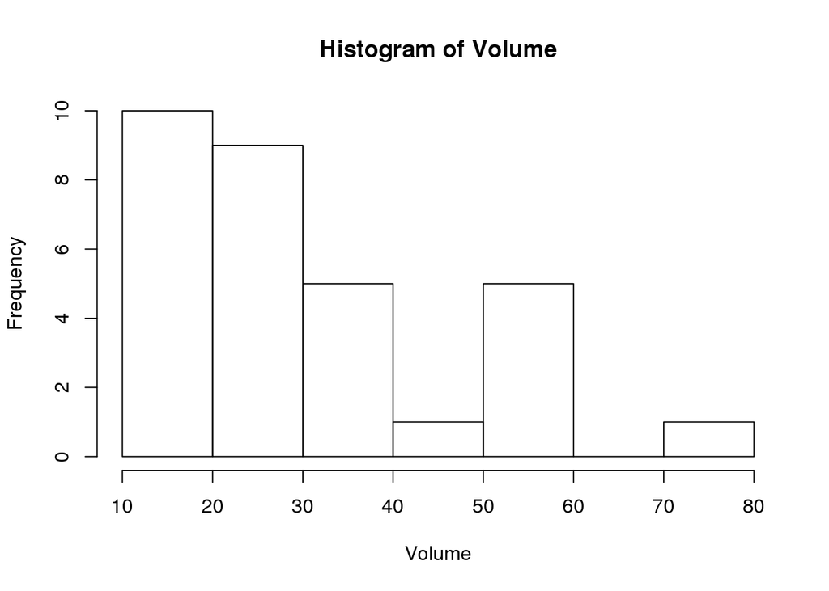

```r
attach(trees)
hist(Volume)
```

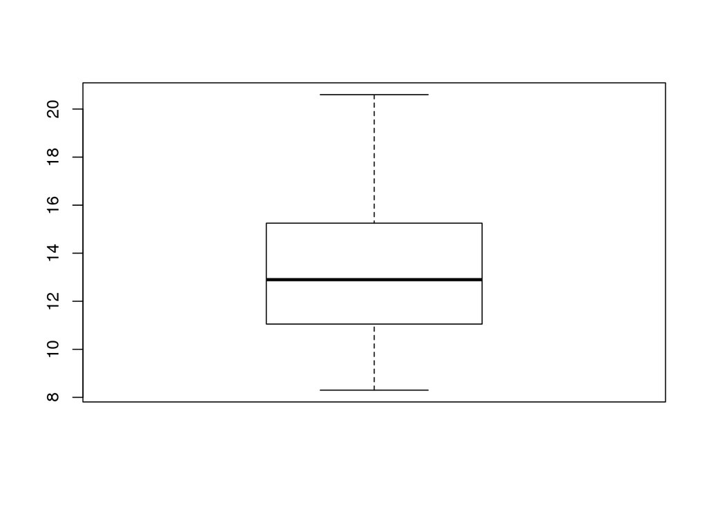

```r
boxplot(Girth)
```

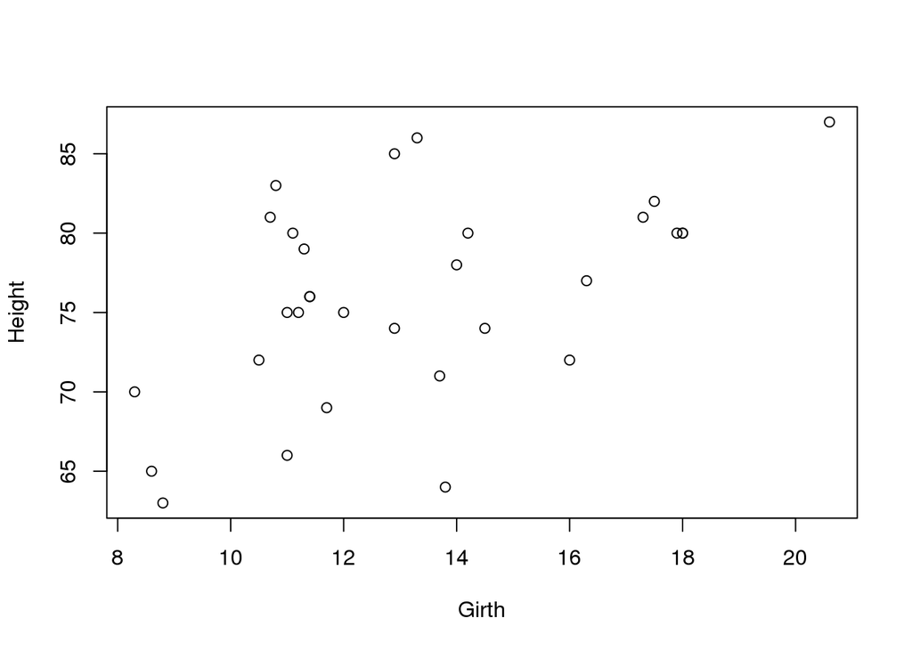

```r
plot(Girth, Height)
```

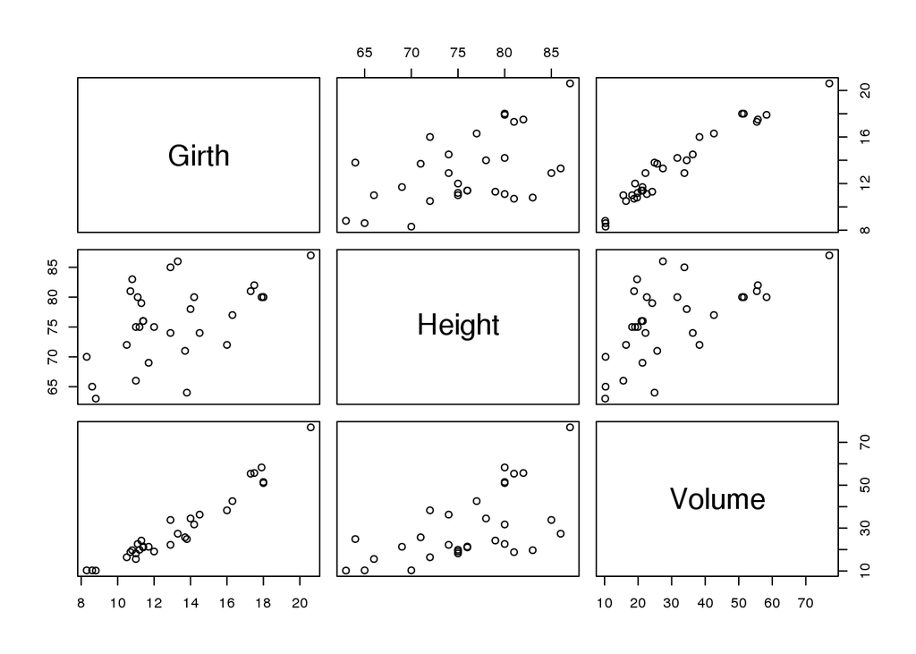

```r
plot(trees)
```

```r
detach(trees)
```

### ۵-خلاصه آماری

چندین تابع بسیار مناسب برای جهت بررسی نوع و خلاصه آماری اشیاء(که بطور معمول مجموعه داده ها می باشند)وجود دارد.

```r
class(trees)
```

```
## [1] "data.frame"
```

```r
str(trees)
```

```
## 'data.frame':    31 obs. of  3 variables:
##  $ Girth : num  8.3 8.6 8.8 10.5 10.7 10.8 11 11 11.1 11.2 ...
##  $ Height: num  70 65 63 72 81 83 66 75 80 75 ...
##  $ Volume: num  10.3 10.3 10.2 16.4 18.8 19.7 15.6 18.2 22.6 19.9 ...
```

```r
summary(trees)
```

```
##      Girth           Height       Volume
##  Min.   : 8.30   Min.   :63   Min.   :10.20
##  1st Qu.:11.05   1st Qu.:72   1st Qu.:19.40
##  Median :12.90   Median :76   Median :24.20
##  Mean   :13.25   Mean   :76   Mean   :30.17
##  3rd Qu.:15.25   3rd Qu.:80   3rd Qu.:37.30
##  Max.   :20.60   Max.   :87   Max.   :77.00
```

```r
summary(trees$Girth)
```

```
##    Min. 1st Qu.  Median    Mean 3rd Qu.    Max.
##    8.30   11.05   12.90   13.25   15.25   20.60
```

```r
c(var(trees$Girth), mean(trees$Girth), min(trees$Girth), max(trees$Girth))
```

```
## [1]  9.847914 13.248387  8.300000 20.600000
```

### ۶-مثال جامع از مباحث بالا

خلاصه ای در مورد داده مورد بحث:سازمان هواشناسی می خواست اطلاعات آماری جاری شدن سیل را با توجه به سطح بارش روزانه در هر شهر را جمع آوری کند. اطلاعات زیر مربوط به یکی از شهرها از سال ۱۳۲۰ الی ۱۳۴۳ می باشد.

```
داده: 1.88 2.23 2.58 2.07 2.94 2.29 3.14 2.14 1.95 2.51 2.86 1.48 1.12 2.76 1.48 1.12
2.76 1.50 2.99 3.48 2.12 4.69 2.29 2.12
```

در اینجا مراحل مروری کوتاه را بر آن باهم مرور می کنیم.

```r
باران = c(1.88, 2.23, 2.58, 2.07, 2.94, 2.29, 3.14, 2.14, 1.95, 2.51, 2.86, 1.48, 1.12,2.76, 1.48, 1.12, 2.76, 1.50, 2.99, 3.48, 2.12, 4.69, 2.29, 2.12)
سال=1320:1343
اطلاعات=data.frame(سال,باران)
summary(اطلاعات)
```

```
##       سال           باران
##  Min.   :1320   Min.   :1.120
##  1st Qu.:1326   1st Qu.:1.933
##  Median :1332   Median :2.260
##  Mean   :1332   Mean   :2.354
##  3rd Qu.:1337   3rd Qu.:2.785
##  Max.   :1343   Max.   :4.690
```

```r
sd(اطلاعات$باران)
```

```
## [1] 0.7994994
```

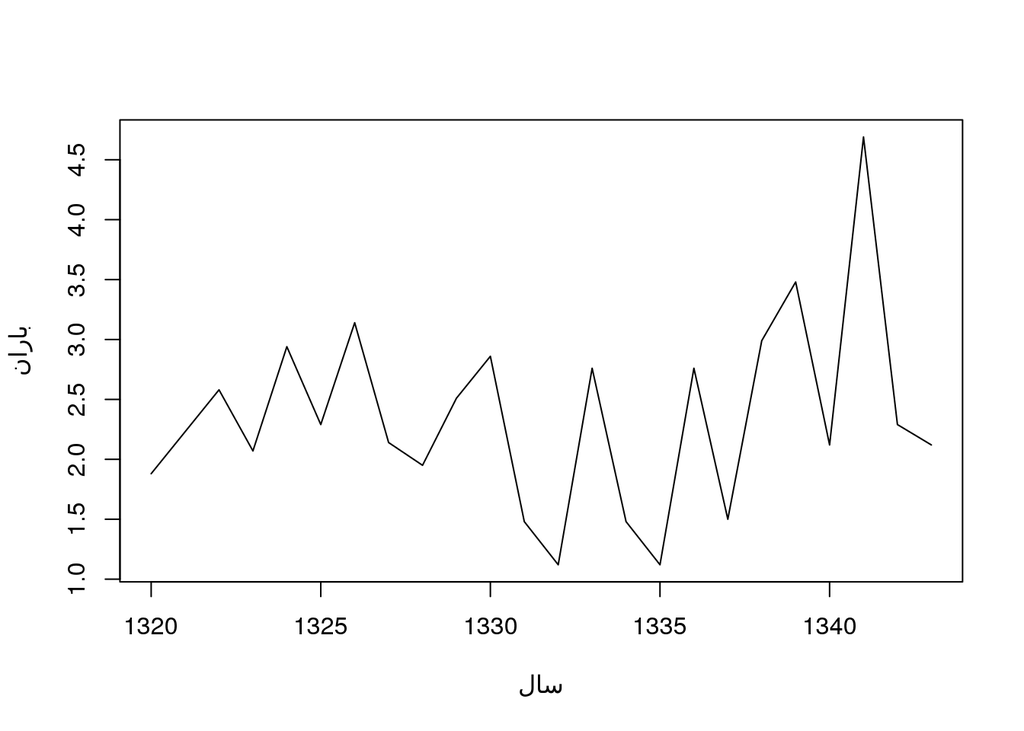

```r
plot(اطلاعات,type="l")
```

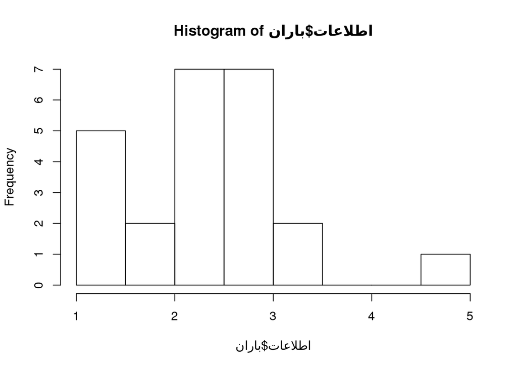

```r
hist(اطلاعات$باران)
```